# AUC & ROC with kNN

Ryan Leslie & SuperPhone/WealthPlan Pro Team GitHub Portfolio

Author

Meaghan Ryan

Let’s use our mnsit data to illustrate the AUC and ROC concepts. We will use the `knn3` model in the`caret` package to classify the data. kNN, by default, does use a majority voting system among the k nearest neighbors to make a classification. This system doesn’t provide a probabilistic output but a class label directly, which seems to conflict with the typical practice of “finding the optimal discriminating threshold”. However, let’s delve a bit deeper to clarify this:

- **Standard kNN:** In its standard form, kNN doesn’t provide a probability estimate but simply a class label based on the majority vote. Hence, without modification, it doesn’t naturally lend itself to producing an ROC curve.
- **Modified kNN:** However, you can modify kNN to provide probability estimates. For instance, instead of just using the majority class among the k nearest neighbors, you can calculate the proportion of neighbors belonging to each class. This proportion can act as a probability estimate for class membership.

```r
library(tidyverse)
library(dslabs)
library(class)
library(pROC)
library(caret)
```

# 1 Load the data

```r
data(mnist_27)
str(mnist_27)
```

```
List of 5
 $ train      :'data.frame':    800 obs. of  3 variables:
  ..$ y  : Factor w/ 2 levels "2","7": 1 1 2 1 2 2 2 1 2 2 ...
  ..$ x_1: num [1:800] 0.1392 0.0909 0.1964 0.2727 0.1556 ...
  ..$ x_2: num [1:800] 0.316 0.299 0.196 0.336 0.2 ...
 $ test       :'data.frame':    200 obs. of  3 variables:
  ..$ y  : Factor w/ 2 levels "2","7": 1 1 1 1 2 2 2 1 2 2 ...
  ..$ x_1: num [1:200] 0.023 0.0617 0.0465 0.046 0.175 ...
  ..$ x_2: num [1:200] 0.264 0.272 0.314 0.322 0.4 ...
 $ index_train: int [1:800] 5167 53374 44258 19964 45808 43920 49362 2333 42549 14742 ...
 $ index_test : int [1:200] 30347 17556 43450 32036 869 27984 12782 54710 54543 15940 ...
 $ true_p     :'data.frame':    15625 obs. of  3 variables:
  ..$ x_1: num [1:15625] 0 0.00422 0.00845 0.01267 0.0169 ...
  ..$ x_2: num [1:15625] 0 0 0 0 0 0 0 0 0 0 ...
  ..$ p  : num [1:15625] 0.702 0.712 0.721 0.73 0.738 ...
  ..- attr(*, "out.attrs")=List of 2
  .. ..$ dim     : Named int [1:2] 125 125
  .. .. ..- attr(*, "names")= chr [1:2] "x_1" "x_2"
  .. ..$ dimnames:List of 2
  .. .. ..$ x_1: chr [1:125] "x_1=0.000000000" "x_1=0.004224270" "x_1=0.008448541" "x_1=0.012672811" ...
  .. .. ..$ x_2: chr [1:125] "x_2=0.000000000" "x_2=0.004928315" "x_2=0.009856631" "x_2=0.014784946" ...
```

```r
table(mnist_27$train$y) # data is well-balanced
```

```
  2   7
401 399
```

```r
#scale the data

train <- mnist_27$train
test <- mnist_27$test

train$x_1 <- scale(mnist_27$train$x_1)
train$x_2 <- scale(mnist_27$train$x_2)

test$x_1 <- scale(mnist_27$test$x_1)
test$x_2 <- scale(mnist_27$test$x_2)
```

# 2 Modified kNN

We can modify kNN to provide probability estimates. For instance, instead of just using the majority class among the k nearest neighbors, we can calculate the proportion of neighbors belonging to each class. This proportion can act as a probability estimate for class membership.

```r
find_probabilities <- function(new_point, k) {
  distances <- sqrt((new_point[1] - train[, 2])^2 + (new_point[2] - train[, 3])^2)
  nearest <- order(distances)[1:k]
  nearest_labels <- train$y[nearest]
  label_proportions <- table(nearest_labels) / k
  return(label_proportions)
}

new_data <- test[, 2:3]
new_prob <- apply(new_data, 1, function(x) find_probabilities(x, k = 21))
new_prob <- t(new_prob)
```

Since we have the predicted probabilities, we can try different thresholds to see how the ROC curve changes. We should first a function that calculates TPR and FPR for a given threshold.

We need to decide the positive class. Let’s say we are interested in the digit 2. Then, we can define the positive class as 2 and the negative class as 7. We can then calculate the TPR and FPR for a given threshold.

```r
# Convert the labels in new_prob to 0 and 1
new_prob <- data.frame(new_prob)
names(new_prob) <- c("prob_2 as 1", "prob_7 as 0")
```

Here is the function that calculates TPR and FPR for a given threshold.

```r
# Function to calculate TPR and FPR at each threshold
calculate_tpr_fpr <- function(prob, true_labels, threshold) {
  if (threshold == 0) {
    predicted_labels <- rep(1, length(prob))
  } else {
    predicted_labels <- ifelse(prob > threshold, 1, 0)
  }

  true_positive <- sum(predicted_labels == 1 & true_labels == 2)
  false_positive <- sum(predicted_labels == 1 & true_labels == 7)
  true_negative <- sum(predicted_labels == 0 & true_labels == 7)
  false_negative <- sum(predicted_labels == 0 & true_labels == 2)

  total_2 = sum(true_labels == 2)
  total_7 = sum(true_labels == 7)

  tpr <- true_positive / total_2
  fpr <- false_positive / total_7
  specificity <- true_negative / total_7

  return(c(tpr, fpr, specificity, true_positive,
           false_positive, true_negative, false_negative,
           threshold, total_2, total_7))
}
```

Now we can plot `tpr` vs `fpr`, which is call the ROC curve

# 3 ROC Curve and AUC

For the digit 2.

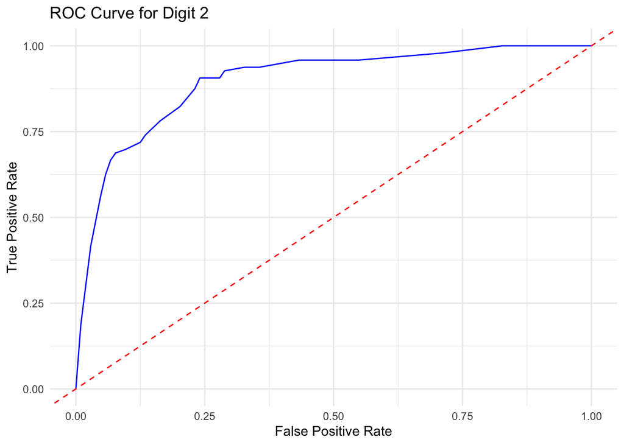

```r
# Define a sequence of thresholds
thresholds <- seq(0, 1, by = 0.01)

# Calculate TPR and FPR for each threshold
tpr_fpr_list <- lapply(thresholds, function(threshold) calculate_tpr_fpr(new_prob[, 1], test$y, threshold))

# Convert the list to a matrix for easier handling
tpr_fpr <- do.call(rbind, tpr_fpr_list)
colnames(tpr_fpr) <- c("tpr", "fpr", "specificity", "true_positive",
                       "false_positive", "true_negative", "false_negative",
                       "threshold", "total_2", "total_7")

ggplot(data.frame(tpr = tpr_fpr[, 1], fpr = tpr_fpr[, 2]), aes(x = fpr, y = tpr)) +
  geom_line(color = "blue") +
  geom_abline(intercept = 0, slope = 1, linetype = "dashed", color = "red") +
  labs(x = "False Positive Rate", y = "True Positive Rate", title = "ROC Curve for Digit 2") +
  theme_minimal()
```

`do.call` is a very useful function in R that allows you to call a function with arguments specified in a list or as a set of arguments. It’s particularly handy when you have a list of arguments and you want to pass them to a function without explicitly writing out each argument. This function is often used in conjunction with functions like `lapply` or `sapply` to simplify and streamline complex operations.

## 3.1 Using `ROCR` and `pROC` packages

### 3.1.1 Using ROCR package

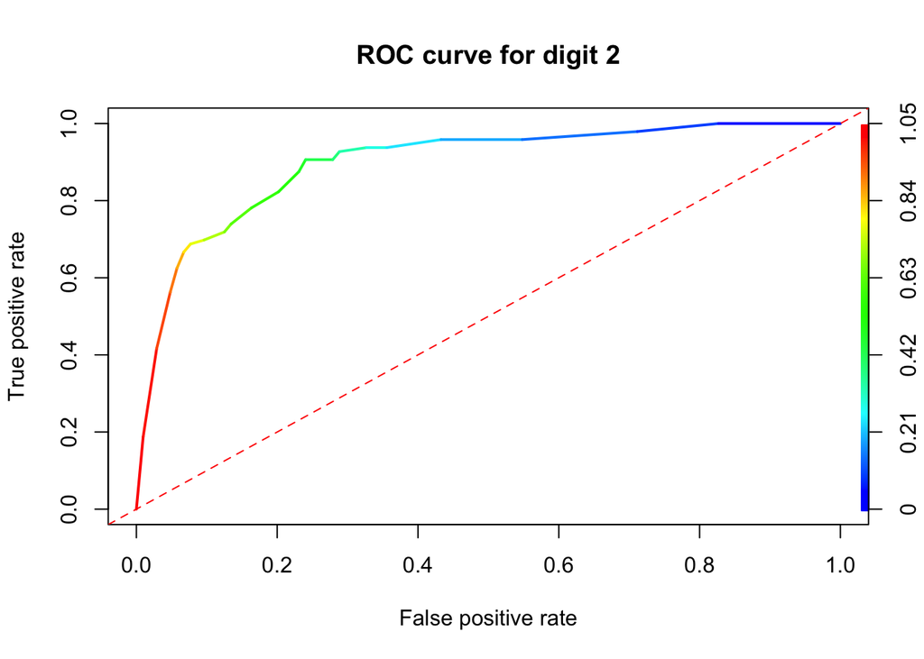

```r
# now let's use ROCR package to plot the ROC curve
library(ROCR)
pred <- prediction(new_prob[, 1], test$y == 2)
perf <- performance(pred, "tpr", "fpr")
plot(perf, lwd = 2,
     main = "ROC curve for digit 2",
     colorize = TRUE)
abline(a = 0, b = 1, lty = 2, col = "red")
```

```r
# And let's calculate the AUC
auc <- performance(pred, "auc")
auc@y.values[[1]]
```

```
[1] 0.8968349
```

The AUC is about 0.90, which is very high. The ROC curve is a graphical representation that plots the True Positive Rate (sensitivity) against the False Positive Rate (1 - specificity) at various threshold settings. The AUC represents **the probability that a randomly chosen positive instance (Digit 2) is ranked higher by the classifier than a randomly chosen negative instance (Digit 7)**. The AUC is a single scalar value that summarizes the performance of the classifier across all possible thresholds.

An AUC of 90% is typically considered very good, as it is close to 1 (or 100%), indicating high separability. An AUC of 50% would indicate no discriminative ability (equivalent to random guessing), and an AUC of 100% would indicate perfect classification.

This measure is particularly useful because it is independent of the threshold chosen to determine the positive class and provides a single measure of performance across all classification thresholds. It is also invariant to changes in the class distribution, making it a good metric for evaluating the intrinsic quality of the model’s predictions.

### 3.1.2 Using pROC package

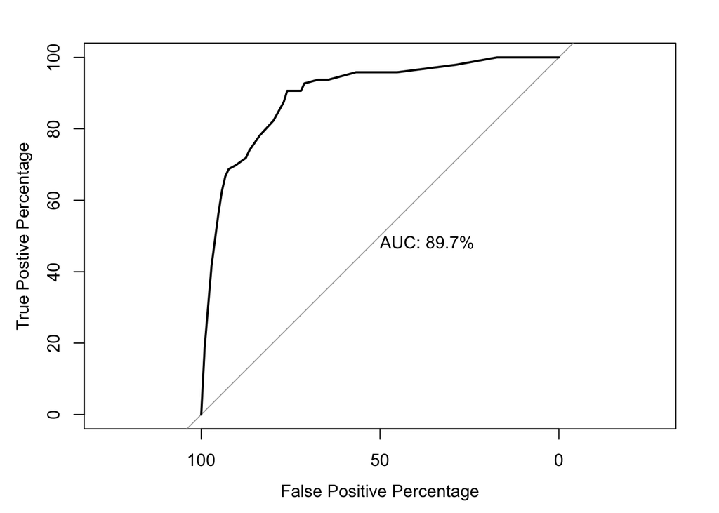

```r
roc_obj <- roc(test$y, new_prob[, 1], levels = c("7", "2"),
               direction = "<", percent = TRUE,
               xlim = c(100, 0), plot = TRUE,
               xlab = "False Positive Percentage", ylab = "True Postive Percentage",
               print.auc = TRUE)
```

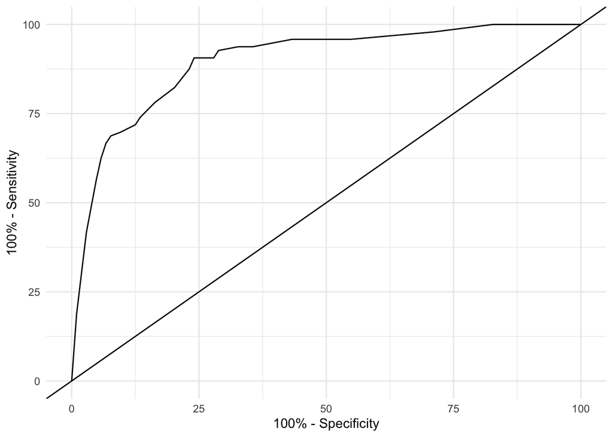

```r
ggroc(roc_obj, legacy.axes = T) +
  geom_abline(slope = 1 ,intercept = 0) + # add identity line
  xlab('100% - Specificity') +
  ylab('100% - Sensitivity') +
  theme_minimal()
```

# 4 Tuning kNN with AUC

## 4.1 Parallel Processing

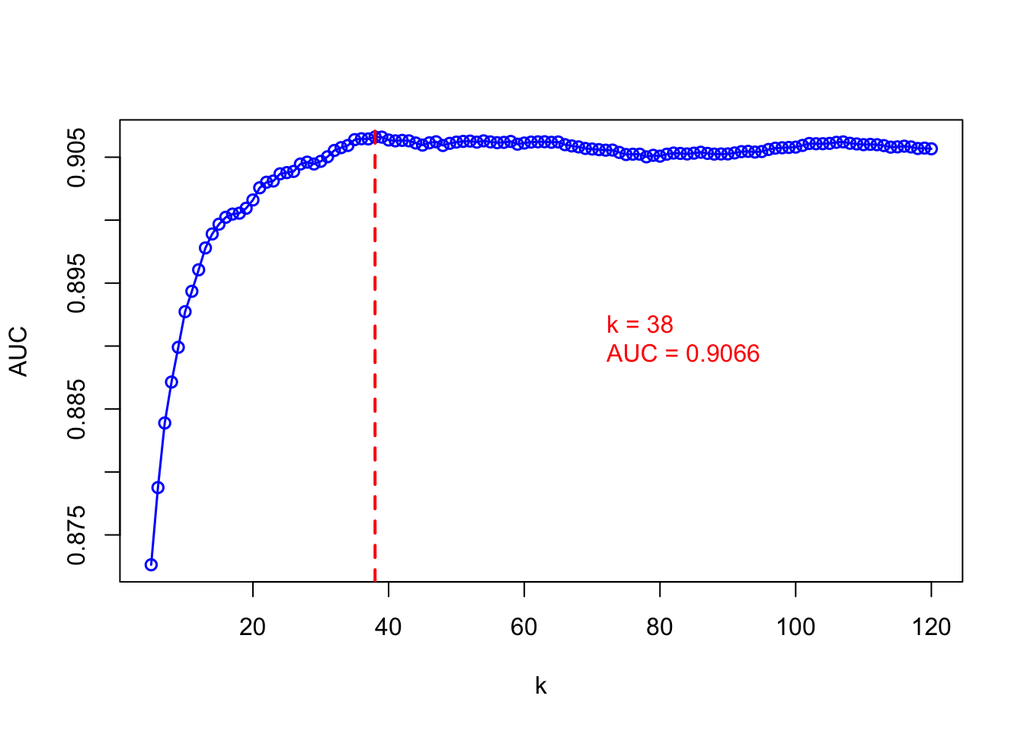

```r
# Let's use the `knn3` model in the `caret` package to classify the data
library(caret)
library(foreach)
library(doParallel)
library(ROCR)

grid <- seq(5, 120, by = 1)

# Register the parallel back-end to use
no_cores <- detectCores() - 1  # reserve one core for the system
cl <- makeCluster(no_cores)
registerDoParallel(cl)

# Using foreach for parallel processing
mauc <- foreach(i = grid, .combine = 'c', .packages = c('caret', "ROCR")) %dopar% {

  aucc <- c()

  for (j in 1:50) {
    set.seed(j)
    ind <- unique(sample(nrow(train), nrow(train), replace = TRUE))
    traint <- train[ind, ]
    val <- train[-ind, ]

    model <- knn3(y ~ ., data = traint, k = i)
    phat <- predict(model, val, type = "prob")

    pred_rocr <- prediction(phat[, 1], val$y == 2)
    auc_rocr <- performance(pred_rocr, "auc")
    aucc[j] <- auc_rocr@y.values[[1]]
  }

  mean(aucc)

}

# Stop the cluster
stopCluster(cl)

# Plot the training AUC vs k
plot(grid, mauc, type = "o", xlab = "k", ylab = "AUC", lwd = 1.5, col = "blue")
optimal_k <- grid[which.max(mauc)]
abline(v = optimal_k, lty = 2, col = "red", lwd = 2)
text(x = 70, y = 0.89, labels = paste("k =", optimal_k, "\nAUC =", round(max(mauc),5)), pos = 4, col = "red")
```

## 4.2 The single core

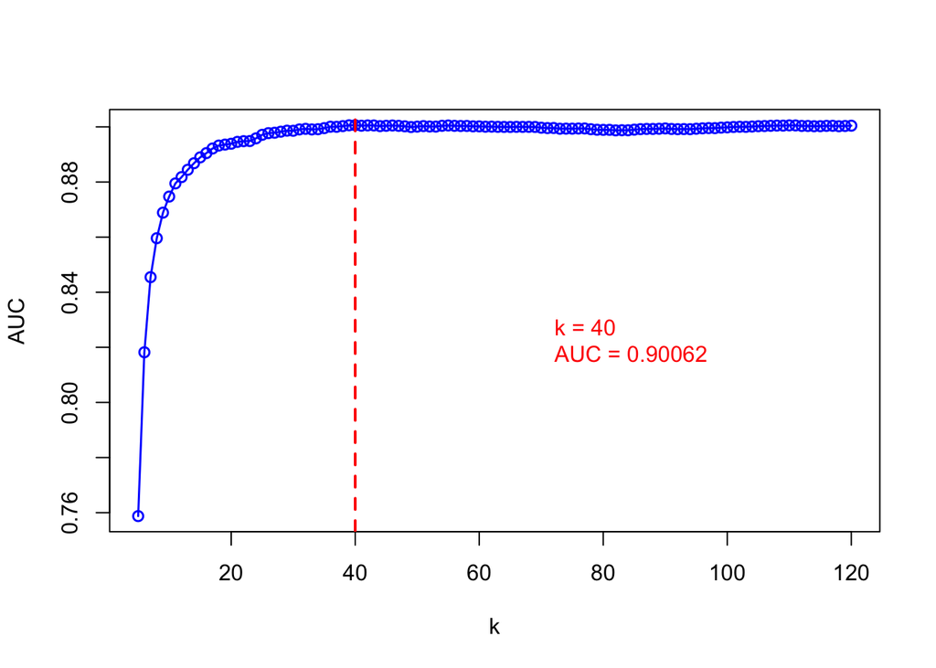

```r
library(caret)
library(foreach)
library(doParallel)
library(ROCR)

grid <- seq(5, 120, by = 1)
mauc <- c()

for (i in 1:length(grid)) {

  aucc <- c()

  for (j in 1:25) {

    set.seed(j)
    ind <- unique(sample(nrow(train), nrow(train), replace = TRUE))
    traint <- train[ind, ]
    val <- train[-ind, ]

    model <- knn3(y ~ ., data = traint, k = i)
    phat <- predict(model, val, type = "prob")

    pred_rocr <- prediction(phat[, 1], val$y == 2)
    auc_rocr <- performance(pred_rocr, "auc")
    aucc[j] <- auc_rocr@y.values[[1]]

  }

  mauc[i] <- mean(aucc)

}


# Plot the training AUC vs k
plot(grid, mauc, type = "o", xlab = "k", ylab = "AUC", lwd = 1.5, col = "blue")
optimal_k <- grid[which.max(mauc)]
abline(v = optimal_k, lty = 2, col = "red", lwd = 2)
text(x = 70, y = 0.82, labels = paste("k =", optimal_k, "\nAUC =", round(max(mauc),5)), pos = 4, col = "red")
```

# 5 Test score and threshold

Now that we’ve tuned our kNN model using AUC on the training data, it’s time to evaluate it on the **held-out test set**. This is the moment of truth—the test set has never been seen during training or hyperparameter tuning, so it gives us an unbiased estimate of how well our model generalizes.

But there’s a subtlety: the model outputs **predicted probabilities**, not class labels directly. To convert probabilities into predictions (e.g., “Digit 2” or “Digit 7”), we need a **discrimination threshold**. By default, we often use 0.5—but is that really the best choice?

## 5.1 Youden’s J statistic

In ROC analysis, the best threshold is often considered to be the one that is furthest away from the line of no-discrimination (the diagonal line from the bottom-left to the top-right in an ROC plot). This point maximizes both sensitivity (true positive rate) and specificity (1 - false positive rate) for the classifier. A common metric used to find this best threshold is **Youden’s J statistic**.

Youden’s index is defined as:

$$J = \text{Sensitivity} + \text{Specificity} - 1$$

or equivalently:

$$J = \text{TPR} + \text{TNR} - 1 = \text{TPR} - \text{FPR}$$

This statistic ranges from 0 to 1, where 0 indicates no discriminative power (equivalent to random guessing), and 1 indicates perfect discrimination. The threshold corresponding to the maximum Youden’s index is often considered the “optimal” cutoff point for decision-making. Geometrically, it is the point on the ROC curve that is **furthest from the diagonal** (the line of no-discrimination).

## 5.2 Test AUC and optimal threshold

Let’s use the optimal k found from the previous section to build our final model, evaluate it on the test set, and find the optimal discrimination threshold.

```r
# Use the optimal k from the tuning section (not hardcoded!)
cat("Using optimal k =", optimal_k, "from tuning\n")
```

```
Using optimal k = 40 from tuning
```

```r
model <- knn3(y ~ ., data = train, k = optimal_k)
phat <- predict(model, test, type = "prob")

# Calculate the test AUC
pred_rocr <- prediction(phat[, 1], test$y == 2)
auc_rocr <- performance(pred_rocr, "auc")
test_auc <- auc_rocr@y.values[[1]]
cat("Test AUC:", round(test_auc, 4), "\n")
```

```
Test AUC: 0.9015
```

```r
# Extract sensitivity and specificity across all thresholds
perf <- performance(pred_rocr, "sens", "spec")
sensitivity <- perf@y.values[[1]]
specificity <- perf@x.values[[1]]

# Calculate Youden's Index at each threshold
youden_index <- sensitivity + specificity - 1

# Find the maximum Youden's index and corresponding cutoff
max_index <- which.max(youden_index)

cat("Maximum Youden's J:", round(youden_index[max_index], 4), "\n")
```

```
Maximum Youden's J: 0.6506
```

```r
cat("Optimal threshold:", round(perf@alpha.values[[1]][max_index], 4), "\n")
```

```
Optimal threshold: 0.725
```

## 5.3 Visualizing the optimal threshold on the ROC curve

The ROC curve below shows the trade-off between sensitivity and specificity at every possible threshold. The red dot marks the **optimal operating point**—the threshold that maximizes Youden’s J statistic. This is the point on the curve that is furthest from the diagonal line of no-discrimination.

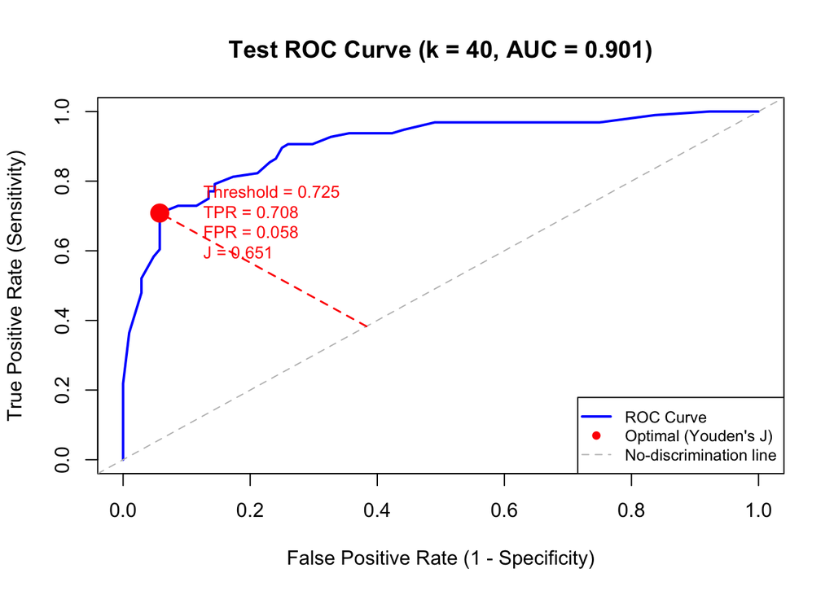

```r
# Get TPR and FPR for plotting the ROC curve
perf_roc <- performance(pred_rocr, "tpr", "fpr")
tpr_vals <- perf_roc@y.values[[1]]
fpr_vals <- perf_roc@x.values[[1]]

# The optimal point on the ROC curve
optimal_threshold <- perf@alpha.values[[1]][max_index]
optimal_tpr <- sensitivity[max_index]
optimal_fpr <- 1 - specificity[max_index]

# Plot the ROC curve with the optimal threshold highlighted
plot(fpr_vals, tpr_vals, type = "l", lwd = 2, col = "blue",
     xlab = "False Positive Rate (1 - Specificity)",
     ylab = "True Positive Rate (Sensitivity)",
     main = paste0("Test ROC Curve (k = ", optimal_k, ", AUC = ", round(test_auc, 3), ")"))
abline(a = 0, b = 1, lty = 2, col = "gray")

# Mark the optimal threshold point
points(optimal_fpr, optimal_tpr, col = "red", pch = 19, cex = 2)

# Draw a line from the diagonal to the optimal point to show Youden's J
# The closest point on the diagonal to (fpr, tpr) where tpr = fpr
mid <- (optimal_fpr + optimal_tpr) / 2
segments(mid, mid, optimal_fpr, optimal_tpr, col = "red", lty = 2, lwd = 1.5)

# Add annotation
text(optimal_fpr + 0.05, optimal_tpr - 0.06,
     labels = paste0("Threshold = ", round(optimal_threshold, 3),
                    "\nTPR = ", round(optimal_tpr, 3),
                    "\nFPR = ", round(optimal_fpr, 3),
                    "\nJ = ", round(youden_index[max_index], 3)),
     pos = 4, col = "red", cex = 0.85)

legend("bottomright", legend = c("ROC Curve", "Optimal (Youden's J)", "No-discrimination line"),
       col = c("blue", "red", "gray"), lty = c(1, NA, 2), pch = c(NA, 19, NA),
       lwd = c(2, NA, 1), cex = 0.8)
```

## 5.4 Default (0.5) vs. optimal threshold

A common question students ask: **“Why not just use 0.5 as the threshold?”** The default threshold of 0.5 assigns the class with the higher probability, which seems intuitive. However, this is only optimal when:

1. The classes are perfectly balanced
2. The costs of false positives and false negatives are equal
3. The model’s predicted probabilities are well-calibrated

In practice, these conditions rarely hold simultaneously. Let’s compare the default 0.5 threshold against the Youden-optimal threshold to see the practical difference:

```r
# Helper function to build a clean confusion matrix and compute metrics
evaluate_threshold <- function(phat, true_labels, threshold, label = "Threshold") {
  predicted <- ifelse(phat[, 1] > threshold, 2, 7)
  predicted <- factor(predicted, levels = c(2, 7))
  actual <- factor(true_labels, levels = c(2, 7))

  cm <- table(Predicted = predicted, Actual = actual)

  tp <- cm["2", "2"]
  fp <- cm["2", "7"]
  fn <- cm["7", "2"]
  tn <- cm["7", "7"]

  accuracy    <- (tp + tn) / sum(cm)
  sensitivity <- tp / (tp + fn)   # TPR
  specificity <- tn / (tn + fp)   # TNR
  precision   <- tp / (tp + fp)   # PPV
  f1          <- 2 * (precision * sensitivity) / (precision + sensitivity)

  cat("\n========================================\n")
  cat(label, "=", round(threshold, 4), "\n")
  cat("========================================\n")
  print(cm)
  cat("\nAccuracy:   ", round(accuracy, 4), "\n")
  cat("Sensitivity:", round(sensitivity, 4), "(TPR - detecting Digit 2)\n")
  cat("Specificity:", round(specificity, 4), "(TNR - correctly ruling out Digit 7)\n")
  cat("Precision:  ", round(precision, 4), "\n")
  cat("F1 Score:   ", round(f1, 4), "\n")

  return(c(accuracy = accuracy, sensitivity = sensitivity,
           specificity = specificity, precision = precision, f1 = f1))
}

# Evaluate at the default 0.5 threshold
metrics_default <- evaluate_threshold(phat, test$y, 0.5, "Default threshold")
```

```
========================================
Default threshold = 0.5
========================================
         Actual
Predicted  2  7
        2 78 18
        7 18 86

Accuracy:    0.82
Sensitivity: 0.8125 (TPR - detecting Digit 2)
Specificity: 0.8269 (TNR - correctly ruling out Digit 7)
Precision:   0.8125
F1 Score:    0.8125
```

```r
# Evaluate at the optimal (Youden) threshold
metrics_optimal <- evaluate_threshold(phat, test$y, optimal_threshold, "Optimal threshold (Youden)")
```

```
========================================
Optimal threshold (Youden) = 0.725
========================================
         Actual
Predicted  2  7
        2 66  6
        7 30 98

Accuracy:    0.82
Sensitivity: 0.6875 (TPR - detecting Digit 2)
Specificity: 0.9423 (TNR - correctly ruling out Digit 7)
Precision:   0.9167
F1 Score:    0.7857
```

```r
# Side-by-side comparison
comparison <- data.frame(
  Metric = c("Accuracy", "Sensitivity (TPR)", "Specificity (TNR)", "Precision", "F1 Score"),
  Default_0.5 = round(metrics_default, 4),
  Optimal_Youden = round(metrics_optimal, 4)
)
comparison$Difference <- comparison$Optimal_Youden - comparison$Default_0.5
print(comparison, row.names = FALSE)
```

```
            Metric Default_0.5 Optimal_Youden Difference
          Accuracy      0.8200         0.8200     0.0000
 Sensitivity (TPR)      0.8125         0.6875    -0.1250
 Specificity (TNR)      0.8269         0.9423     0.1154
         Precision      0.8125         0.9167     0.1042
          F1 Score      0.8125         0.7857    -0.0268
```